# Question 5

## Does transcript length or number of exons predict its coding potential?

All transcript RNA's in the data base are classified into two categories, coding (for protien) or noncoding (do not code for protien). To determine what causes an RNA to become coding or non coding we use the Logistic Regression Model. We have two continues variable in our database that we can use in our model to help use determine coding potential they are number of exons in the transcript and transcript length.

We begin by installing needed packages an libraries

```r
library(caret)
library(dplyr)
library(regclass)
library(ggplot2)
```

Although we do not explicitly have a length column varaible each trascript has a start and end point in the data we get the length by subtracting start from the end.

```r
myData <- read.csv(file.choose())
myData <- mutate(myData, length = myData$end - myData$start)
```

Next we grab an even random sample of coding and noncoding transcripts to produce a balanced data set

```r
coding <- myData[myData$CNIT_out == "coding",][c("num_exons","length","CNIT_out")]
noncoding <- myData[myData$CNIT_out == "noncoding",][c("num_exons","length","CNIT_out")]
nrow(noncoding)
```

```
## [1] 61263
```

```r
nrow(coding)
```

```
## [1] 94972
```

```r
reducedCoding <- sample_n(coding,61263)
balanced_data <- rbind(reducedCoding,noncoding)
```

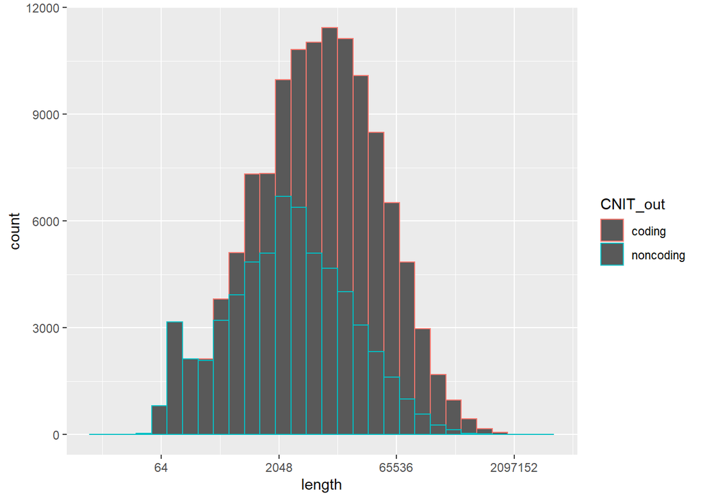

```r
ggplot(data=balanced_data, aes(x=length, color=CNIT_out)) +
  scale_x_continuous(trans='log2') + geom_histogram()
```

First step partition the data into trainig and test data

```r
set.seed(123)
traing.samples <- balanced_data$CNIT_out %>% createDataPartition(p = 0.6, list = FALSE)
train.data <- balanced_data[traing.samples, ]
test.data <- balanced_data[-traing.samples, ]
```

Generate logistic model for length and coding status

```r
model <- glm(CNIT_out ~ length, data = train.data, family = binomial)
summary(model)$coef
```

```
##                  Estimate   Std. Error   z value Pr(>|z|)
## (Intercept)  3.721362e-01 9.095101e-03  40.91611        0
## length      -1.856959e-05 3.149018e-07 -58.96948        0
```

R tends round p-values that are very low to 0. However we Know that since the p-value is less than 0.05 length is significant in the prediction rna transcripts being coding or noncoding.

Now we move on to check the accuracy of this model.

Make confusion matrix

```r
confusion_matrix(model)
```

```
##                  Predicted coding Predicted noncoding Total
## Actual coding               15560               21198 36758
## Actual noncoding             4978               31780 36758
## Total                       20538               52978 73516
```

Using confusion matrix above we can see that total accuracy is 64%

```r
47279 / 73516
```

```
## [1] 0.6431117
```

Sensitivity: (ability to predict coding) 42%

```r
15520 / 36758
```

```
## [1] 0.422221
```

Specificity: (ability to predict noncoding) 86%

```r
31759 / 36758
```

```
## [1] 0.8640024
```

From above we can see that this model although significant is only truely accurate in the prediction non coding RNA. Next we take a look at the model for number of exon in predicting coding potential.

```r
model <- glm(CNIT_out ~ num_exons , data = train.data, family = binomial)
summary(model)$coef
```

```
##               Estimate  Std. Error   z value Pr(>|z|)
## (Intercept)  2.0648863 0.017789920  116.0706        0
## num_exons   -0.4943518 0.004401737 -112.3083        0
```

same as above we can see that our model is significant by our p-value

now we test accuracy

```r
confusion_matrix(model)
```

```
##                  Predicted coding Predicted noncoding Total
## Actual coding               23982               12776 36758
## Actual noncoding             4060               32698 36758
## Total                       28042               45474 73516
```

We can see that the model exon count to predict coding potential we get overall much better accuracy with the total accuracy being 77%.

```r
56760 / 73516
```

```
## [1] 0.7720768
```

Sensitivity: 65%

```r
24062 / 36758
```

```
## [1] 0.6546058
```

Specificity: 89%

```r
32698 / 36758
```

```
## [1] 0.8895479
```

We can see that this model is much better than the first in terms of accuracy as all three total, sensitivity and specificity have better results. Again we have the best accuracy in predicting noncoding transcripts.

In our final model we test both length and number of exons to predict coding potential.

```r
model <- glm(CNIT_out ~ num_exons + length, data = train.data, family = binomial)
summary(model)$coef
```

```
##                  Estimate   Std. Error     z value     Pr(>|z|)
## (Intercept)  2.068514e+00 1.782455e-02  116.048613 0.000000e+00
## num_exons   -4.993428e-01 4.584867e-03 -108.911076 0.000000e+00
## length       7.827554e-07 1.904387e-07    4.110276 3.951872e-05
```

We can see that this model is also significant in predicting coding potential. With both length and number of exons showing significant p-values.

Now we move on to compares this models accuracy

```r
confusion_matrix(model)
```

```
##                  Predicted coding Predicted noncoding Total
## Actual coding               23976               12782 36758
## Actual noncoding             4059               32699 36758
## Total                       28035               45481 73516
```

Total Accuracy: 77%

```r
56643 / 73516
```

```
## [1] 0.7704853
```

Sensitivity: 65%

```r
23943 / 36758
```

```
## [1] 0.6513684
```

Specificity: 89%

```r
32700 / 36758
```

```
## [1] 0.8896023
```

Overall the accuracy of the model is extremely similar to the prevous adding length did not make a significant difference to the accuracy of the model.

Conclusion:

Logistic Regression is a significant model in the prediction of coding potential on transcripts. However, it is the most accurate in terms of specificity that is does best when used to predict if an RNA Transcript does not code for protien. This may be most usefull for scientist who are trying to find noncoding transcrips in a sample.

## Final Outcomes and Analysis

### [Question 1 Report](http://www.itss.brockport.edu/~jlee7/csc435/question1.html)

### [Question 2 Report](http://www.itss.brockport.edu/~jlee7/csc435/question2.html)

### [Question 3 Report](http://www.itss.brockport.edu/~jlee7/csc435/question3.html)

### [Question 4 Report](http://www.itss.brockport.edu/~jlee7/csc435/question4.html)

### [Homepage](http://www.itss.brockport.edu/~jlee7/csc435/index.html)